# Final Project Rough Draft

Adharsh Vanchinathan

Due 3/13/2020

Problem Statement:

Could internet access be a path to more educated, economically powerful country?

“Using the key internet access indicators, we are able to contrast each country’s economic and educational data with their internet access data, providing clear patterns by plotting the data.”

# Introduction

The Internet has been a juggernaut of social and cultural change, bringing people together and providing forums and spaces to voice their opinions, display their creative efforts, and even conduct business. However, many of us with access to it take the internet and its effects for granted. Could internet access be a path to more educated, economically powerful country? The effects of internet access and how the access inequality affects countries as a whole has not been extensively studied, and may provide insight into why internet infrastructure is a necessary investment for a 21st century government. By collecting data on the numbers of non-cellular internet users, % of population that are mobile internet users, % of population who are internet users, and comparing it to their population, GDP, GDP per Capita, and national average learning outcomes, we will attempt to shed more light on the potential of internet access as a key indicator for future success. Using the key internet access indicators, we are able to contrast each country’s economic and educational data with their internet access data, providing clear patterns by plotting the data.

## Package Setup

```r
knitr::opts_chunk$set(eval = T, warning = F, message = F)
# Change the scipen option to 999 to prevent Scientific Notation
options(scipen = 999)

# The tidyverse package is loaded in to allow for ease of data manipulation
# And the start up message is suppressed
suppressPackageStartupMessages(library(tidyverse))
# ggpubr package allows for subplotting (like in matplotlib in Python)
suppressPackageStartupMessages(library(ggpubr))
```

## Citations

- Internet users/availability

The entity, year and number of internet users was selected to show the data that is important to exemplify the number of internet users.

Roser, Max, et al. “Internet, how many internet users does each country have/number of internet users by country.” Our World in Data, 14 July 2015, ourworldindata.org/internet.

- Smartphone users

The mobile cellular subscriptions per 100 people data was selected by entity, year and mobile subscriptions and filtered by the country. This data is important because it shows the amount of mobile subscriptions.

Roser, Max, et al. “Internet, Mobile Phone Users/Mobile cellular subscriptions per 100 people.” Our World in Data, 14 July 2015, ourworldindata.org/internet.

- Percent of population internet usage

Roser, Max, et al. “Internet, how many internet users does each country have/share of population using the internet.” Our World in Data, 14 July 2015, ourworldindata.org/internet.

- Users by social media platform

Users by social media data was used to show the number of people using social media platforms. This data was filtered to show the data for the specific social media platforms: Facebook, Instagram, Reddit, YouTube.

Roser, Max, et al. “Internet, The Rise of Social Media/Number of people using social media platforms.” Our World in Data, 14 July 2015, ourworldindata.org/internet.

- Population

Global Population by Country was used to compare countries and provide scale for percent values.

Datopian. “Population, Total.” DataHub, datahub.io/world-bank/sp.pop.totl. Economics and Education data:

- GDP

The Gross Domestic Product data exemplifies which of the selected countries are above or below the world average, as well as how they compare to each other.

Datopian. “Country, Regional and World GDP (Gross Domestic Product).” DataHub, datahub.io/core/gdp.

- National average learning outcome

The average learning outcome (ALO) is used to compare education standards.

Roser, Max, and Esteban Ortiz-Ospina. “Global Education.” Our World in Data, 31 Aug. 2016, ourworldindata.org/global-education.

# Data Prep:

There are two major categories of data, Internet specific data, and comparison data. All of our internet specific data and the National Average Learning Outcome(ALO) comes from ourworldindata.org, an organization dedicated to “making knowledge on the big problems accessible and understandable.” These datasets in particular were sourced from The World Bank database. This data was collected to help explore the short but impactful history of the internet. The research was published in 2020, however the datasets end around 2017.The population and GDP data was gathered and hosted on Datahub by Datopian. It is also from the World Bank. The mobile percent data sometimes exceeds 100%, but this may be due to people having multiple sim cards, a practice common in many countries with subpar information infrastructure.

## Internet Data

- Internet users/availability

This data shows the number of internet users by country (USA Data shown)

```r
net_users_raw <- as_tibble(read.csv(file = "Data/number-of-internet-users-by-country.csv")) %>% rename(Num_Net_Users = Number.of.internet.users..users.)
net_users_wld <- net_users_raw %>% filter(Entity == "World") %>% select(Entity,Year,Num_Net_Users) %>% arrange(Year)
net_users_raw %>% filter(Code == "USA") %>% head()
```

```
## # A tibble: 6 x 4
##   Entity        Code   Year Num_Net_Users
##   <fct>         <fct> <int>         <dbl>
## 1 United States USA    1990       1981674
## 2 United States USA    1991       2965851
## 3 United States USA    1992       4439033
## 4 United States USA    1993       5906809
## 5 United States USA    1994      12776546
## 6 United States USA    1995      24539142
```

- Smartphone users

This data shows the number of mobile users per 100 people (USA Data shown)

```r
mobile_use_raw <- as_tibble(read.csv(file = "Data/mobile-cellular-subscriptions-per-100-people.csv")) %>% rename(Mobile_Per_100 = Mobile.cellular.subscriptions..per.100.people...per.100.people.) %>% filter(Year > 1989)
mobile_use_wld <- mobile_use_raw %>% filter(Entity == "World") %>% select(Entity, Year, Mobile_Per_100 ) %>% arrange(Year)
mobile_use_raw %>% filter(Code == "USA") %>% head()
```

```
## # A tibble: 6 x 4
##   Entity        Code   Year Mobile_Per_100
##   <fct>         <fct> <int>          <dbl>
## 1 United States USA    1990           2.09
## 2 United States USA    1991           2.96
## 3 United States USA    1992           4.29
## 4 United States USA    1993           6.16
## 5 United States USA    1994           9.19
## 6 United States USA    1995          12.7
```

- % of pop internet usage

This data shows the share of individuals using the internet (USA Data Shown)

```r
net_per_raw <- as.tibble(read.csv(file = "Data/share-of-individuals-using-the-internet.csv")) %>% rename(Percent_Internet =Individuals.using.the.Internet....of.population.....of.population.)
net_per_wld <- net_per_raw %>% filter(Entity == "World") %>% select(Entity,Year,Percent_Internet) %>% arrange(Year)
net_per_raw %>% filter(Code == "USA") %>% head()
```

```
## # A tibble: 6 x 4
##   Entity        Code   Year Percent_Internet
##   <fct>         <fct> <int>            <dbl>
## 1 United States USA    1990            0.785
## 2 United States USA    1991            1.16
## 3 United States USA    1992            1.72
## 4 United States USA    1993            2.27
## 5 United States USA    1994            4.86
## 6 United States USA    1995            9.24
```

- Users by Social Media Platform

This data shows the user populations of various social media platforms

```r
sm_user_raw <- as.tibble(read.csv(file = "Data/users-by-social-media-platform.csv"))
sm_user <- sm_user_raw %>% rename(Monthly_Users = Monthly.active.users..Statista.and.TNW..2019....MAU.) %>% filter(Entity == "Facebook"| Entity == "Instagram"|Entity == "Reddit"|Entity == "YouTube")
sm_user
```

```
## # A tibble: 41 x 4
##    Entity   Code   Year Monthly_Users
##    <fct>    <lgl> <int>         <dbl>
##  1 Facebook NA     2008     100000000
##  2 Facebook NA     2009     276000000
##  3 Facebook NA     2010     517750000
##  4 Facebook NA     2011     766000000
##  5 Facebook NA     2012     979750000
##  6 Facebook NA     2013    1170500000
##  7 Facebook NA     2014    1334000000
##  8 Facebook NA     2015    1516750000
##  9 Facebook NA     2016    1753500000
## 10 Facebook NA     2017    2035750000
## # ... with 31 more rows
```

## Population Data

This data shows population by country (USA Data)

```r
pop_raw <- as.tibble(read.csv(file = "Data/population.csv")) %>% rename(pop = Value) %>% filter(Year > 1989)
wld_pop <- pop_raw %>% filter(Country.Name == "World")
pop_raw %>% filter(Country.Code == "USA") %>% head()
```

```
## # A tibble: 6 x 4
##   Country.Name  Country.Code  Year       pop
##   <fct>         <fct>        <int>     <dbl>
## 1 United States USA           1990 249623000
## 2 United States USA           1991 252981000
## 3 United States USA           1992 256514000
## 4 United States USA           1993 259919000
## 5 United States USA           1994 263126000
## 6 United States USA           1995 266278000
```

## Economics and Education Data

- GDP

This data shows the Gross Domestic Product(GDP) as the economic statistic (USA Data)

```r
GDP <-read.csv(file = "Data/gdp_csv.csv")%>% rename(GDP = Value) %>% filter(Year > 1989)
GDP_wld<- GDP %>% filter(Country.Name == "World")
GDP %>% filter(Country.Code == "USA") %>% head()
```

```
##    Country.Name Country.Code Year           GDP
## 1 United States          USA 1990 5979589000000
## 2 United States          USA 1991 6174043000000
## 3 United States          USA 1992 6539299000000
## 4 United States          USA 1993 6878718000000
## 5 United States          USA 1994 7308755000000
## 6 United States          USA 1995 7664060000000
```

- Average Learning Outcome(ALO)

This data shows the National Average Learning Outcome(ALO) as the educational statistic (USA Data)

```r
ALO_tbl <- as.tbl(read.csv(file = "Data/average-harmonized-learning-outcome-scores.csv")) %>% filter(Code != "") %>% rename(ALO = Average.harmonised.learning.outcome.score..Altinok..Angrist..and.Patrinos..2018......score..) %>% filter(Year%%5 == 0,Year >= 1990)

ALO_tbl %>% filter(Code == "USA") %>% head()
```

```
## # A tibble: 6 x 4
##   Entity        Code   Year   ALO
##   <fct>         <fct> <int> <dbl>
## 1 United States USA    1990  494.
## 2 United States USA    1995  506.
## 3 United States USA    2000  511.
## 4 United States USA    2005  515.
## 5 United States USA    2010  524.
## 6 United States USA    2015  529.
```

Variables of Interest:

- Num_Net_Users
- Mobile_per_100
- Percent_Internet
- Monthly_Users
- pop
- GDP
- ALO

# World Data

## Create DF with World Data (wld_data)

Using the data we just gathered and discussed, we must first show the trends of the data as a whole, using World data to determine how the countries we explore compare to the global average. First we consolidate the disparate dataframes into one `wld_data` Dataframe.

```r
wld_data <- full_join(wld_pop,net_users_wld,by = "Year") %>% left_join(mobile_use_wld, by = "Year") %>% left_join(net_per_wld, by = "Year") %>% left_join(GDP_wld, by = "Year") %>% select(Entity = Country.Name.y, Year, pop, Num_Net_Users, Mobile_Per_100, Percent_Internet, GDP) %>% mutate(mobile_pop = (Mobile_Per_100*.01)*pop) %>% mutate(GDP_Capita = GDP/pop)
wld_data
```

```
## # A tibble: 27 x 9
##    Entity  Year    pop Num_Net_Users Mobile_Per_100 Percent_Internet     GDP
##    <fct>  <int>  <dbl>         <dbl>          <dbl>            <dbl>   <dbl>
##  1 World   1990 5.28e9       2630452          0.211           0.0493 2.26e13
##  2 World   1991 5.37e9            NA          0.302          NA      2.39e13
##  3 World   1992 5.46e9            NA          0.427          NA      2.54e13
##  4 World   1993 5.54e9      14073444          0.618           0.252  2.59e13
##  5 World   1994 5.62e9      25348069          0.989           0.447  2.78e13
##  6 World   1995 5.71e9      44714405          1.58            0.777  3.09e13
##  7 World   1996 5.79e9      77323781          2.50            1.33   3.16e13
##  8 World   1997 5.88e9     120719713          3.65            2.04   3.14e13
##  9 World   1998 5.96e9     188144724          5.33            3.14   3.13e13
## 10 World   1999 6.04e9     281428387          8.12            4.64   3.25e13
## # ... with 17 more rows, and 2 more variables: mobile_pop <dbl>,
## #   GDP_Capita <dbl>
```

## Plotting

### Population, Internet users, mobile users

First, lets graph the world population, number of mobile subscriptions, and the number of broadband/wi-fi internet users. This graph clearly illustrates how pervasive technology is in our modern lives.

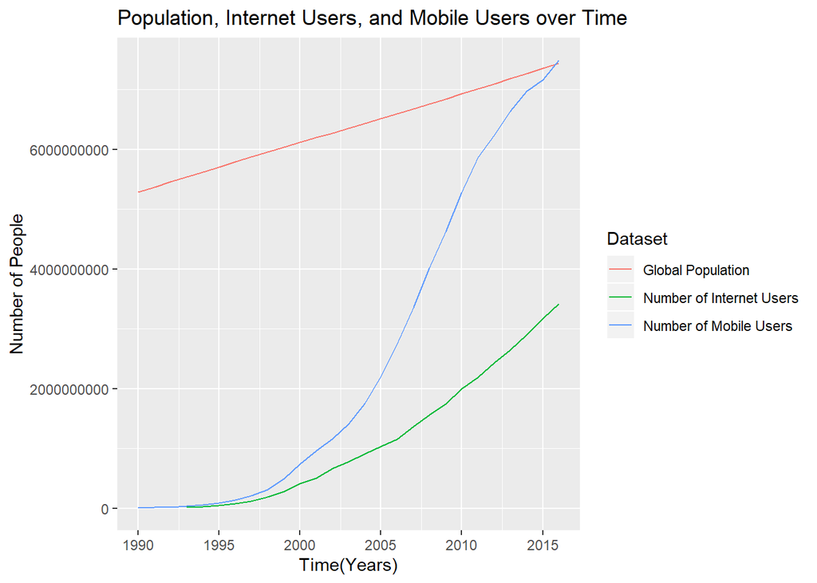

```r
ggplot(wld_data)+
  geom_line(aes(Year,pop, color = "Global Population"))+
  geom_line(aes(Year,Num_Net_Users, color = "Number of Internet Users"))+
  geom_line(aes(Year,mobile_pop, color = "Number of Mobile Users"))+
  scale_x_continuous(limits = c(1990,2016), breaks = c(1990,1995,2000,2005,2010,2015))+
  scale_color_discrete("Dataset")+
  labs(title = "Population, Internet Users, and Mobile Users over Time",x = "Time(Years)", y = "Number of People")
```

```r
# Make it Pretty
```

### GDP

Now we graph the GDP per Capita to provide a mean baseline to judge our selected countries how they compare to the global average.

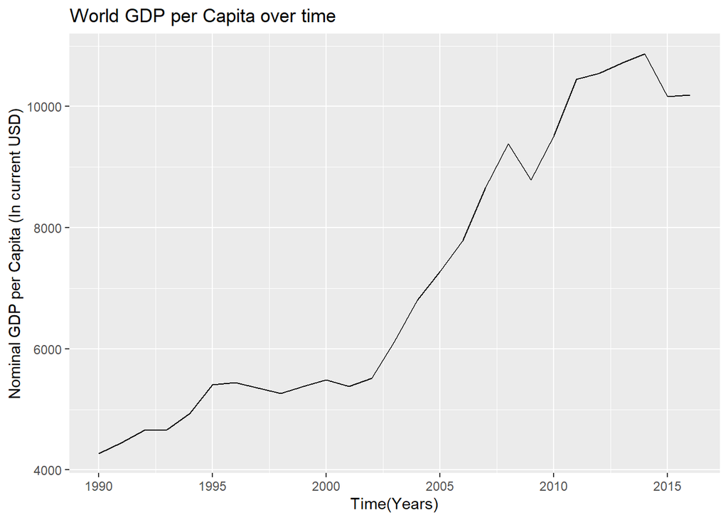

```r
ggplot(wld_data)+
  geom_line(aes(Year,GDP_Capita))+
  scale_x_continuous(limits = c(1990,2016), breaks = c(1990,1995,2000,2005,2010,2015))+
  labs(title = "World GDP per Capita over time", x = "Time(Years)", y = "Nominal GDP per Capita (In current USD)")
```

### Internet and Mobile Users (%)

Then we analyse the world Mobile User and Internet users by percent(%). This is again just a baseline to compare the our selected countries.

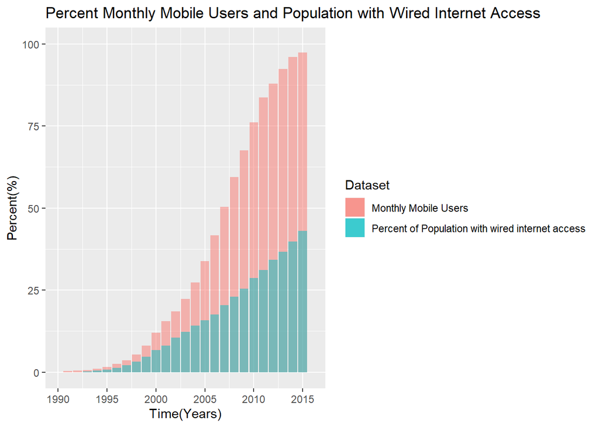

```r
mob_100 <- mobile_use_wld %>% select(Year, val = Mobile_Per_100)
per_int <- net_per_wld %>% filter(Year < 2016) %>% select(Year,val = Percent_Internet)
ggplot(NULL, aes(Year, val)) +
  geom_col(aes(fill = "Monthly Mobile Users"), data = mob_100, alpha = 0.5,position = "dodge") +
  geom_col(aes(fill = "Percent of Population with wired internet access"), data = per_int, alpha =
  0.5,position = "dodge")+
  scale_y_continuous(limits = c(0,100))+
  scale_x_continuous(limits = c(1990,2016), breaks = c(1990,1995,2000,2005,2010,2015))+
  scale_fill_discrete("Dataset")+
  labs(title = "Percent Monthly Mobile Users and Population with Wired Internet Access ", x = "Time(Years)",
  y = "Percent(%)")
```

### Social Media

With Social Media being a major contributor to the rapid assimilation of the internet, it can that over barely a decade, industry titans like Facebook and Youtube have over 1.5 billion monthly users.

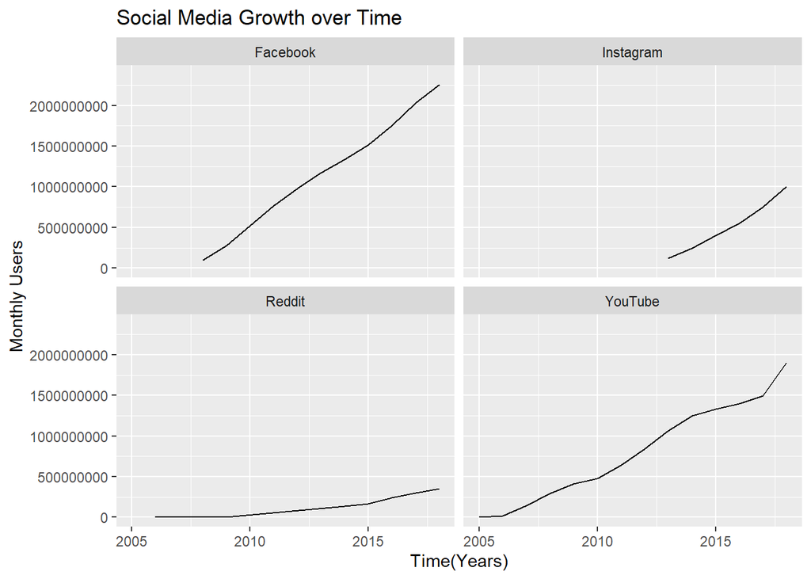

```r
ggplot(sm_user)+
  geom_line(aes(Year,Monthly_Users))+
  scale_x_continuous(limits = c(2005,2018), breaks = c(2005,2010,2015))+
  facet_wrap(vars(Entity))+
  labs(title = "Social Media Growth over Time", x = "Time(Years)", y = "Monthly Users")
```

# Country Comparisons

Now lets compare pairs of countries to see how what their similarities and differences can tell us about their respective situations.

## France and Germany

Lets compare the two largest rivals in the EU.

### Making the Dataframe(s)

First we create FR and DE dataframes to combine and create a World-France-Germany dataframe to make comparisons

```r
FR_data <- left_join(pop_raw %>% filter(Country.Code == "FRA"),net_users_raw %>% filter(Code == "FRA"),by = "Year") %>% left_join(mobile_use_raw %>% filter(Code == "FRA"), by = "Year") %>% left_join(net_per_raw %>% filter(Code == "FRA")) %>% left_join(GDP) %>% filter(Country.Code == "FRA")%>% left_join(ALO_tbl) %>% filter(Code == "FRA") %>% select(Entity,Year,pop,Num_Net_Users,Mobile_Per_100,Percent_Internet,GDP,ALO) %>% mutate(mobile_pop = (Mobile_Per_100*.01)*pop)
FR_data %>% head()
```

```
## # A tibble: 6 x 9
##   Entity  Year    pop Num_Net_Users Mobile_Per_100 Percent_Internet     GDP
##   <chr>  <int>  <dbl>         <dbl>          <dbl>            <dbl>   <dbl>
## 1 France  1990 5.85e7         30063          0.497           0.0528 1.28e12
## 2 France  1991 5.86e7         80198          0.655           0.140  1.28e12
## 3 France  1992 5.89e7        160445          0.760           0.279  1.41e12
## 4 France  1993 5.91e7        341052          0.991           0.591  1.33e12
## 5 France  1994 5.93e7        521839          1.52            0.900  1.40e12
## 6 France  1995 5.95e7        953970          2.24            1.64   1.61e12
## # ... with 2 more variables: ALO <dbl>, mobile_pop <dbl>
```

```r
DE_data <- left_join(pop_raw %>% filter(Country.Code == "DEU"),net_users_raw %>% filter(Code == "DEU"),by = "Year") %>% left_join(mobile_use_raw %>% filter(Code == "DEU"), by = "Year") %>% left_join(net_per_raw %>% filter(Code == "DEU")) %>% left_join(GDP) %>% filter(Country.Code == "DEU") %>% left_join(ALO_tbl) %>% filter(Code == "DEU") %>% select(Entity = Country.Name,Year,pop,Num_Net_Users,Mobile_Per_100,Percent_Internet,GDP,ALO) %>% mutate(mobile_pop = (Mobile_Per_100*.01)*pop)
DE_data %>% head()
```

```
## # A tibble: 6 x 9
##   Entity  Year    pop Num_Net_Users Mobile_Per_100 Percent_Internet     GDP
##   <chr>  <int>  <dbl>         <dbl>          <dbl>            <dbl>   <dbl>
## 1 Germa~  1990 7.94e7         99604          0.345            0.126 1.76e12
## 2 Germa~  1991 8.00e7        199129          0.669            0.250 1.86e12
## 3 Germa~  1992 8.06e7        348429          1.21             0.435 2.12e12
## 4 Germa~  1993 8.12e7        373319          2.20             0.464 2.07e12
## 5 Germa~  1994 8.14e7        746622          3.08             0.923 2.21e12
## 6 Germa~  1995 8.17e7       1492989          4.59             1.84  2.59e12
## # ... with 2 more variables: ALO <dbl>, mobile_pop <dbl>
```

```r
WFD_data <- bind_rows(wld_data,FR_data,DE_data) %>% mutate(GDP_Capita = GDP/pop)
WFD_data
```

```
## # A tibble: 81 x 10
##    Entity  Year    pop Num_Net_Users Mobile_Per_100 Percent_Internet     GDP
##    <chr>  <int>  <dbl>         <dbl>          <dbl>            <dbl>   <dbl>
##  1 World   1990 5.28e9       2630452          0.211           0.0493 2.26e13
##  2 World   1991 5.37e9            NA          0.302          NA      2.39e13
##  3 World   1992 5.46e9            NA          0.427          NA      2.54e13
##  4 World   1993 5.54e9      14073444          0.618           0.252  2.59e13
##  5 World   1994 5.62e9      25348069          0.989           0.447  2.78e13
##  6 World   1995 5.71e9      44714405          1.58            0.777  3.09e13
##  7 World   1996 5.79e9      77323781          2.50            1.33   3.16e13
##  8 World   1997 5.88e9     120719713          3.65            2.04   3.14e13
##  9 World   1998 5.96e9     188144724          5.33            3.14   3.13e13
## 10 World   1999 6.04e9     281428387          8.12            4.64   3.25e13
## # ... with 71 more rows, and 3 more variables: mobile_pop <dbl>,
## #   GDP_Capita <dbl>, ALO <dbl>
```

Two countries that have been intertwined since their inceptions. Both economic and cultural powerhouses of Western Europe, this comparison will help us have a frame of reference for further inquiry.

### Population

First we compare the Populations of France and Germany. Germany has had a consistently higher population despite the dip in the early 2010’s. France, however, has been steadily growing during the entire timeframe.

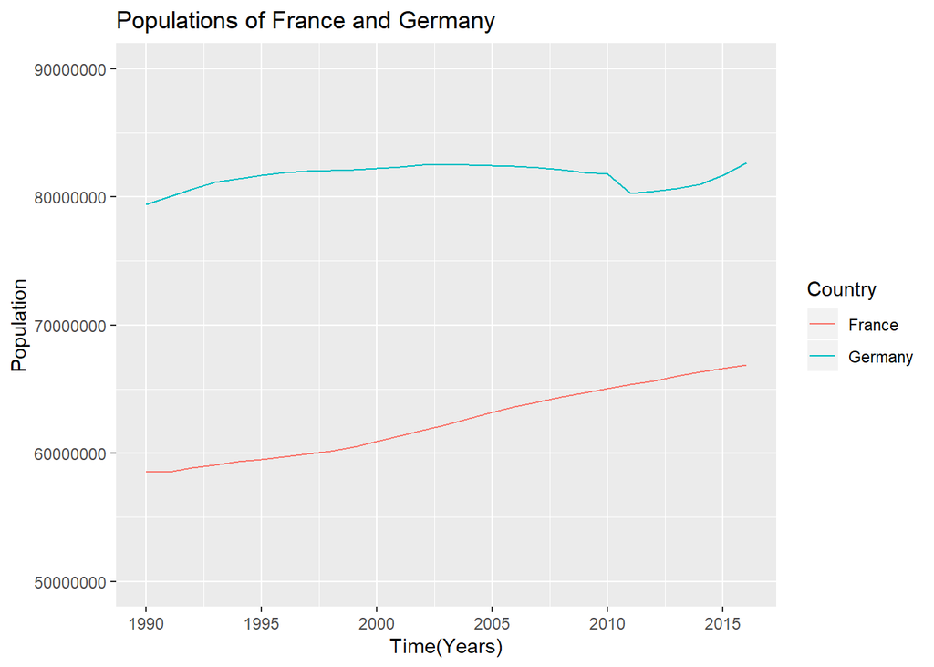

```r
ggplot(WFD_data %>% filter(Entity != "World"))+
  geom_line(aes(Year,pop,color = Entity))+
  scale_color_brewer(type = "qual", palette = 6, aesthetics = "color")+
  scale_y_continuous(limits = c(50000000,90000000))+
  scale_x_continuous(limits = c(1990,2016), breaks = c(1990,1995,2000,2005,2010,2015))+
  scale_color_discrete("Country")+
  labs(title = "Populations of France and Germany", x = "Time(Years)", y = "Population")
```

### Internet Infrastructure

Both these countries have wildly better internet access than the world average, and it will not be hard to see why. As hubs of tourism, industry, manufacturing, design, and commerce, these countries need to be equipped with robust and powerful internet infrastructure and access to keep up with the other global powerhouses, such as China and the USA.

Now the internet access graphs for both countries

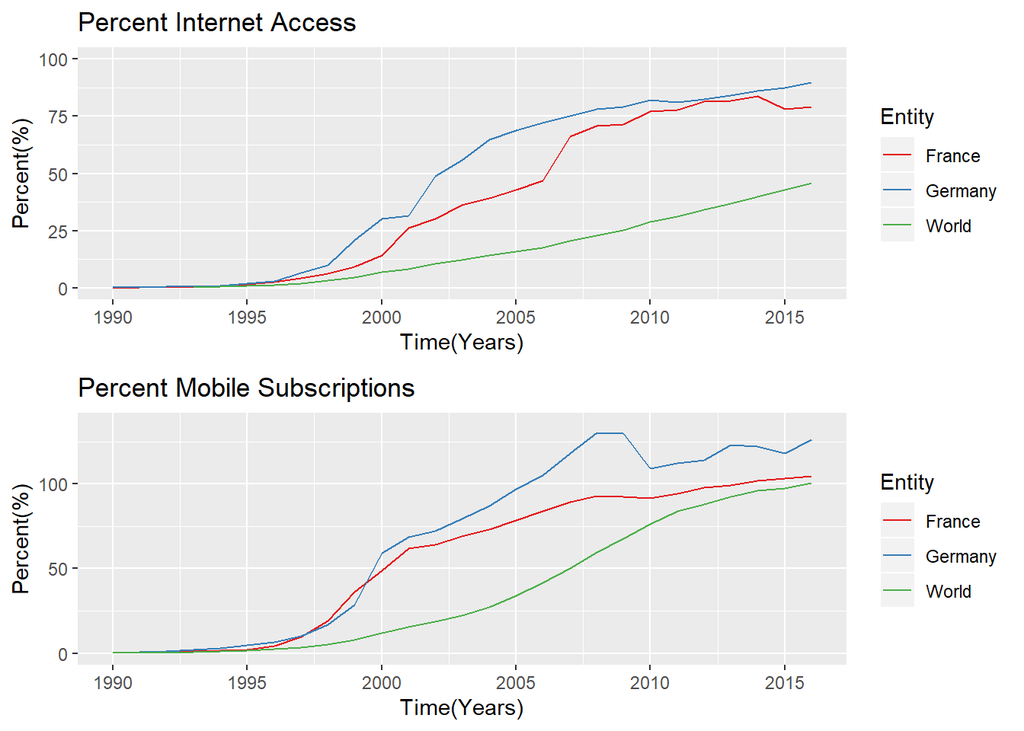

```r
WFD_PI <- ggplot(WFD_data)+
  geom_line(aes(Year,Percent_Internet, color = Entity))+
  scale_color_brewer(type = "qual", palette = 6, aesthetics = "color")+
  scale_y_continuous(limits = c(0,100))+
  scale_x_continuous(limits = c(1990,2016), breaks = c(1990,1995,2000,2005,2010,2015))+
  labs(title = "Percent Internet Access" ,x = "Time(Years)", y = "Percent(%)")


WFD_PM <- ggplot(WFD_data)+
  geom_line(aes(Year,Mobile_Per_100, color = Entity))+
  scale_color_brewer(type = "qual", palette = 6, aesthetics = "color")+
  scale_y_continuous(limits = c(0,135))+
  scale_x_continuous(limits = c(1990,2016), breaks = c(1990,1995,2000,2005,2010,2015))+
  labs(title = "Percent Mobile Subscriptions",x = "Time(Years)", y = "Percent(%)")

ggarrange(WFD_PI,WFD_PM,nrow = 2,ncol = 1)
```

### GDP per Capita

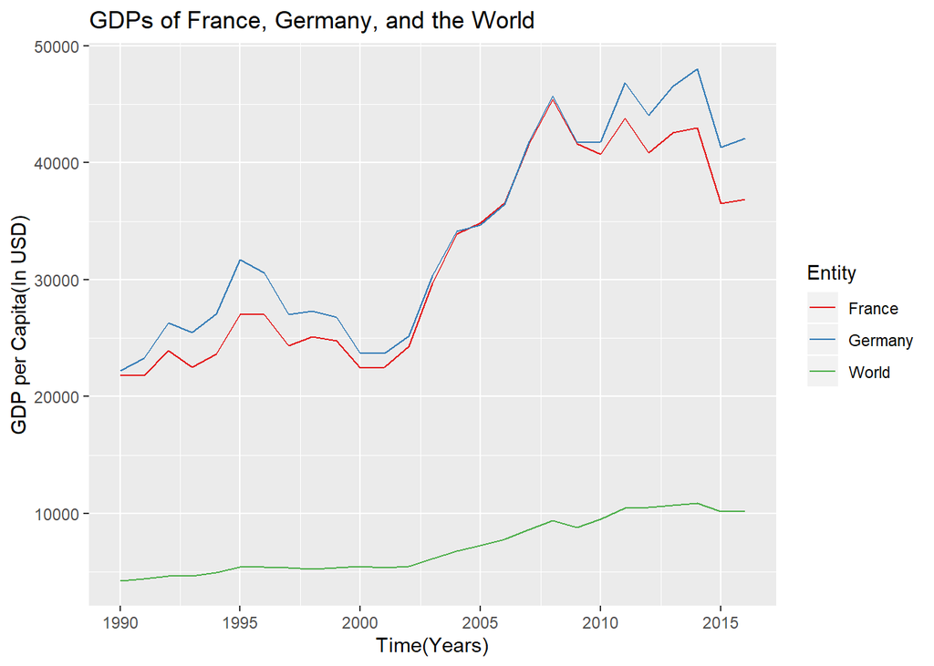

```r
ggplot(WFD_data)+ #%>% filter(Entity != "World"))+
  geom_line(aes(Year,GDP_Capita, color = Entity))+
  scale_color_brewer(type = "qual", palette = 6, aesthetics = "color")+
  scale_x_continuous(limits = c(1990,2016), breaks = c(1990,1995,2000,2005,2010,2015))+
  labs(title = "GDPs of France, Germany, and the World", x = "Time(Years)", y = "GDP per Capita(In USD)")
```

### Education

The ALO’s of both these countries are so close their difference is nearly negligible.

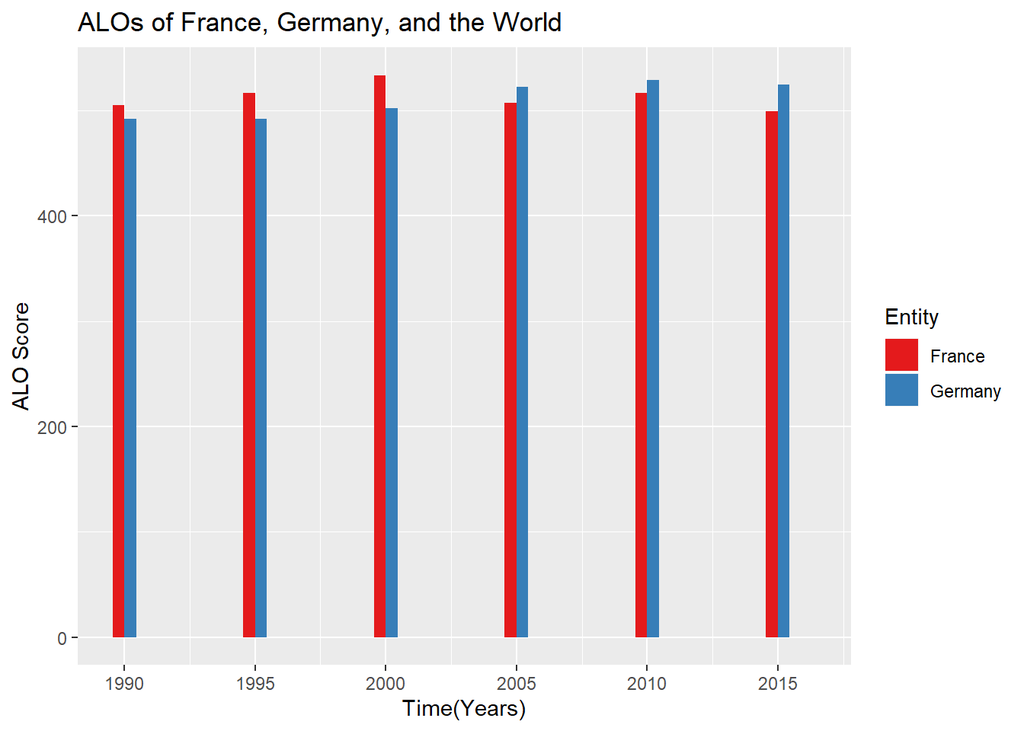

```r
ggplot(WFD_data %>% filter(Entity != "World"))+
  geom_col(aes(Year,ALO, fill = Entity), position = "dodge")+
  scale_color_brewer(type = "qual", palette = 6, aesthetics = "fill")+
  scale_x_continuous( breaks = c(1990,1995,2000,2005,2010,2015))+
  labs(title = "ALOs of France, Germany, and the World", x = "Time(Years)", y = "ALO Score")
```

Starting with the French in a slight advantage, over the years the scene changes and Germany is on top, but still marginally. Both these countries are quite similar in terms of their education standards, economic output, and internet access. While Germany is better by a hair, both are star examples of a developed, modern country.

## South Korea and Myanmar

Moving onto South Korea and Myanmar, both these countries are located in Asia and have similar populations throughout the timeframe . By comparing their internet access, economies and education, we can start to see the association between population and prosperity.

### Making the Dataframe(s)

We import South Korea data into an independent dataframe

```r
SK_data <- left_join(pop_raw %>% filter(Country.Code == "KOR"),net_users_raw %>% filter(Code == "KOR"),by = "Year") %>% left_join(mobile_use_raw %>% filter(Code == "KOR"), by = "Year") %>% left_join(net_per_raw %>% filter(Code == "KOR")) %>% left_join(GDP) %>% filter(Country.Code == "KOR")%>% left_join(ALO_tbl) %>% filter(Code == "KOR") %>%  select(Entity,Year,pop,Num_Net_Users,Mobile_Per_100,Percent_Internet,GDP,ALO) %>% mutate(mobile_pop = (Mobile_Per_100*.01)*pop)
SK_data
```

```
## # A tibble: 27 x 9
##    Entity  Year    pop Num_Net_Users Mobile_Per_100 Percent_Internet     GDP
##    <chr>  <int>  <dbl>         <dbl>          <dbl>            <dbl>   <dbl>
##  1 South~  1990 4.29e7          9986          0.186           0.0233 2.79e11
##  2 South~  1991 4.33e7         20008          0.383           0.0461 3.26e11
##  3 South~  1992 4.37e7         43154          0.620           0.0984 3.50e11
##  4 South~  1993 4.42e7        110828          1.06            0.250  3.86e11
##  5 South~  1994 4.46e7        139570          2.14            0.311  4.56e11
##  6 South~  1995 4.51e7        371307          3.62            0.820  5.56e11
##  7 South~  1996 4.55e7        743208          6.95            1.62   5.98e11
##  8 South~  1997 4.60e7       1663664         14.9             3.60   5.58e11
##  9 South~  1998 4.63e7       3162187         30.1             6.78   3.74e11
## 10 South~  1999 4.66e7      11075156         49.9            23.6    4.85e11
## # ... with 17 more rows, and 2 more variables: ALO <dbl>, mobile_pop <dbl>
```

We import Myanmar data into independent dataframe

```r
MM_data <- left_join(pop_raw %>% filter(Country.Code == "MMR"),net_users_raw %>% filter(Code == "MMR"),by = "Year") %>% left_join(mobile_use_raw %>% filter(Code == "MMR"), by = "Year") %>% left_join(net_per_raw %>% filter(Code == "MMR")) %>% left_join(GDP) %>% filter(Country.Code == "MMR") %>% left_join(ALO_tbl) %>% filter(Code == "MMR") %>% select(Entity = Country.Name,Year,pop,Num_Net_Users,Mobile_Per_100,Percent_Internet,GDP,ALO) %>% mutate(mobile_pop = (Mobile_Per_100*.01)*pop) %>% filter(Year >=1999)
MM_data
```

```
## # A tibble: 17 x 9
##    Entity  Year    pop Num_Net_Users Mobile_Per_100 Percent_Internet      GDP
##    <chr>  <int>  <dbl>         <dbl>          <dbl>            <dbl>    <dbl>
##  1 Myanm~  1999 4.55e7            69         0.0250         0.000152 NA
##  2 Myanm~  2001 4.66e7           135         0.0486         0.000289  6.48e 9
##  3 Myanm~  2002 4.71e7           201         0.102          0.000426  6.78e 9
##  4 Myanm~  2003 4.76e7         11461         0.140          0.0241    1.05e10
##  5 Myanm~  2004 4.81e7         11700         0.192          0.0243    1.06e10
##  6 Myanm~  2005 4.85e7         31630         0.265          0.0652    1.20e10
##  7 Myanm~  2006 4.88e7         88924         0.439          0.182     1.45e10
##  8 Myanm~  2007 4.92e7        106766         0.504          0.217     2.02e10
##  9 Myanm~  2008 4.95e7        108855         0.743          0.22      3.19e10
## 10 Myanm~  2009 4.98e7        109562         1.01           0.22      3.69e10
## 11 Myanm~  2010 5.02e7        125390         1.18           0.25      4.95e10
## 12 Myanm~  2011 5.06e7        495420         2.46           0.98      6.00e10
## 13 Myanm~  2012 5.10e7       2039461         7.31           4         5.99e10
## 14 Myanm~  2013 5.14e7       4115856        13.3            8         6.03e10
## 15 Myanm~  2014 5.19e7       5981666        55.9           11.5       6.54e10
## 16 Myanm~  2015 5.24e7      11385134        78.2           21.7       5.97e10
## 17 Myanm~  2016 5.29e7      13260073        95.7           25.1       6.32e10
## # ... with 2 more variables: ALO <dbl>, mobile_pop <dbl>
```

We combine the world, Korea and Myanmar data into WKM_data

```r
WKM_data <- bind_rows(wld_data ,SK_data,MM_data) %>%
  filter(Year >= 2001)%>% mutate(GDP_Capita = GDP/pop)
WKM_data
```

```
## # A tibble: 48 x 10
##    Entity  Year    pop Num_Net_Users Mobile_Per_100 Percent_Internet     GDP
##    <chr>  <int>  <dbl>         <dbl>          <dbl>            <dbl>   <dbl>
##  1 World   2001 6.20e9     502668939           15.5             8.08 3.34e13
##  2 World   2002 6.28e9     664809555           18.5            10.5  3.46e13
##  3 World   2003 6.36e9     780750279           22.2            12.2  3.89e13
##  4 World   2004 6.44e9     912821319           27.3            14.1  4.38e13
##  5 World   2005 6.52e9    1029023007           33.8            15.7  4.74e13
##  6 World   2006 6.60e9    1158678340           41.6            17.5  5.14e13
##  7 World   2007 6.68e9    1369818178           50.3            20.4  5.79e13
##  8 World   2008 6.76e9    1558290574           59.5            23.0  6.35e13
##  9 World   2009 6.85e9    1742929484           67.6            25.4  6.02e13
## 10 World   2010 6.93e9    1999332784           76.1            28.7  6.60e13
## # ... with 38 more rows, and 3 more variables: mobile_pop <dbl>,
## #   GDP_Capita <dbl>, ALO <dbl>
```

### Population

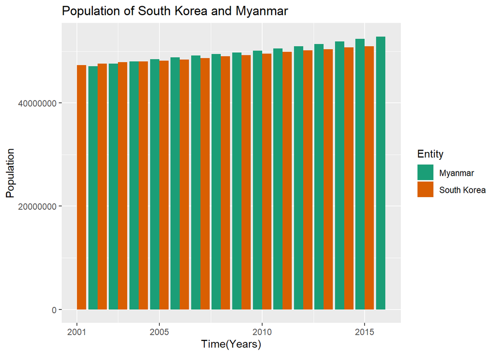

```r
ggplot(WKM_data %>% filter(Entity != "World"))+
  geom_col(aes(Year,pop,fill = Entity),position = "dodge")+
  scale_color_brewer(type = "qual", palette = 2, aesthetics = "fill")+
  scale_x_continuous(limits = c(2001,2016), breaks = c(2001,2005,2010,2015))+
  labs(title="Population of South Korea and Myanmar", x = "Time(Years)", y = "Population")
```

Now to compare their internet coverage

### Internet Infrastructure

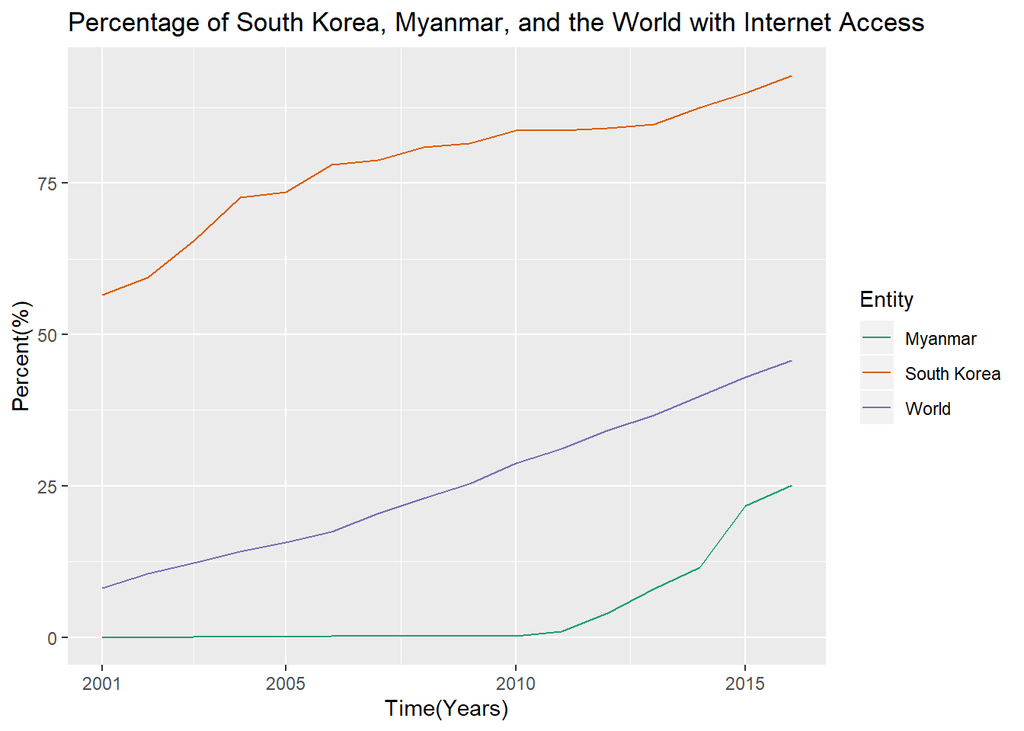

```r
ggplot(WKM_data)+
  geom_line(aes(Year,Percent_Internet, color = Entity))+
  scale_color_brewer(type = "qual", palette = 2, aesthetics = "color")+
  scale_x_continuous(limits = c(2001,2016), breaks = c(2001,2005,2010,2015))+
  labs(title = "Percentage of South Korea, Myanmar, and the World with Internet Access" ,x = "Time(Years)",
  y = "Percent(%)")
```

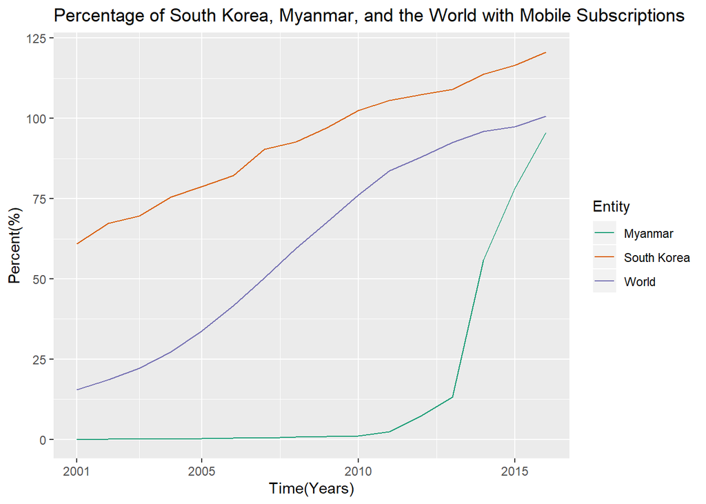

```r
ggplot(WKM_data)+
  geom_line(aes(Year,Mobile_Per_100, color = Entity))+
  scale_color_brewer(type = "qual", palette = 2, aesthetics = "color")+
  scale_x_continuous(limits = c(2001,2016), breaks = c(2001,2005,2010,2015))+
  labs(title = "Percentage of South Korea, Myanmar, and the World with Mobile Subscriptions" ,x = "Time(Years)",
  y = "Percent(%)")
```

### GDP per Capita

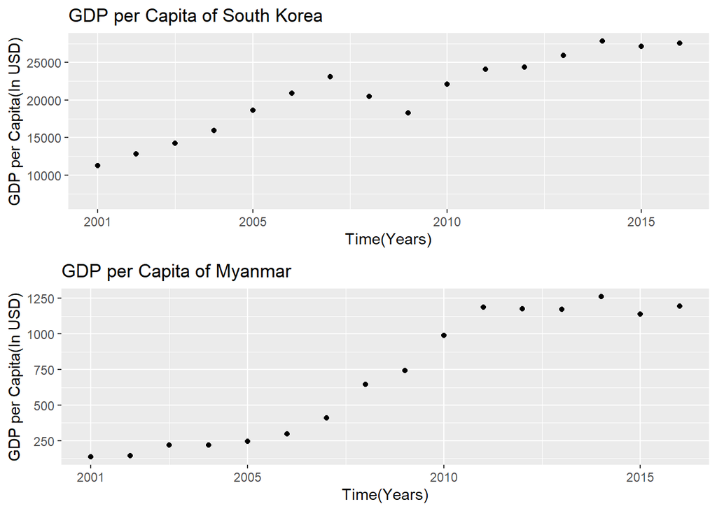

```r
SK_GDP <- ggplot(SK_data)+
  geom_point(aes(Year,GDP/pop))+
  scale_x_continuous(limits = c(2001,2016), breaks = c(2001,2005,2010,2015))+
  labs(title = "GDP per Capita of South Korea" ,x = "Time(Years)",
  y = "GDP per Capita(In USD)")

MM_GDP <- ggplot(MM_data)+
  geom_point(aes(Year,GDP/pop))+
  scale_x_continuous(limits = c(2001,2016), breaks = c(2001,2005,2010,2015))+
  labs(title = "GDP per Capita of Myanmar" ,x = "Time(Years)",
  y = "GDP per Capita(In USD)")




WKM_GDP <- ggplot(WKM_data)+
  geom_point(aes(Year,GDP_Capita, color = Entity))+
  scale_color_brewer(type = "qual", palette = 2, aesthetics = "color")+
  scale_x_continuous(limits = c(2001,2016), breaks = c(2001,2005,2010,2015))+
  labs(title = "GDP per Capita" ,x = "Time(Years)",
  y = "GDP per Capita(In USD)")

ggarrange(SK_GDP,MM_GDP,nrow = 2,ncol = 1)
```

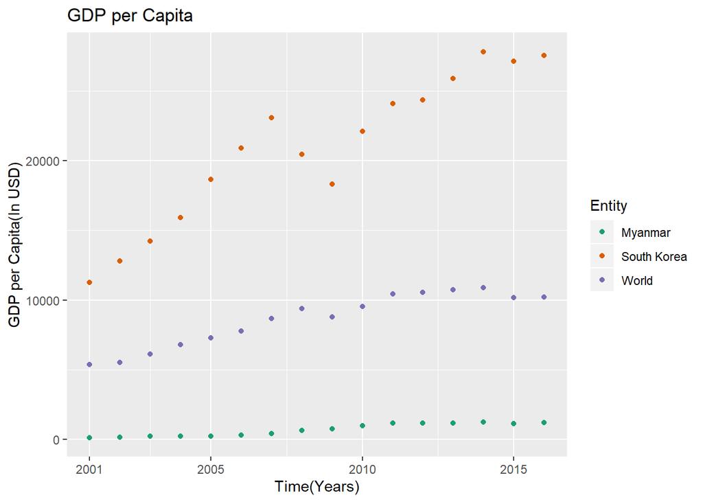

```r
WKM_GDP
```

### Education

Myanmar does not have any ALO information, which speaks volumes about the status of education and recordkeeping in general, but South Korea has consistently scored higher than Germany, so it would suffice it to say South Korea is far more educated than Myanmar based on the previous analyses. This shows that not only does internet access beget wealth, but wealth begets internet access.

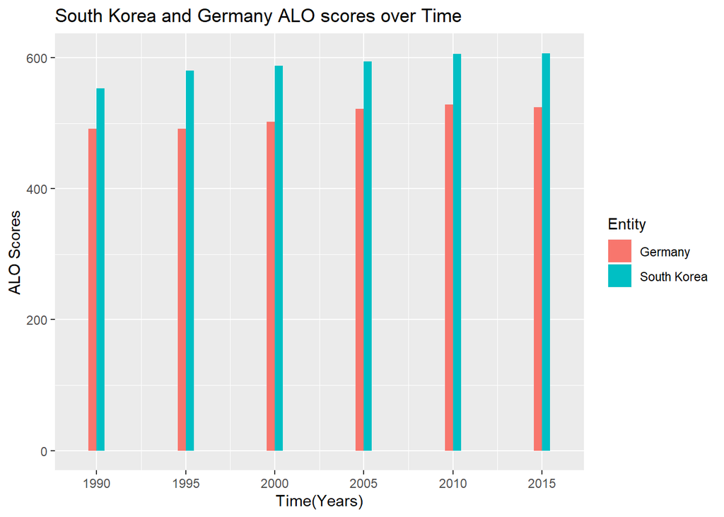

```r
DK_data <- bind_rows(DE_data,SK_data)

ggplot(DK_data, aes(Year,ALO))+
  geom_col(aes(fill = Entity),position = "dodge")+
  scale_color_discrete("Country")+
  scale_x_continuous(limits = c(1989,2016), breaks = c(1990,1995,2000,2005,2010,2015))+
  labs(title = "South Korea and Germany ALO scores over Time", x = "Time(Years)", y = "ALO Scores")
```

## Canada and Thailand

Finally, Two countries with a similar number of wired internet users by 2016. Lets assess Canada and Thailand, two extremely different countries, in terms of their cultures and histories.

### Making the Dataframe(s)

We load in each country into their own dataframes and combine them into WCT_data

```r
CA_data <- left_join(pop_raw %>% filter(Country.Code == "CAN"),net_users_raw %>% filter(Code == "CAN"),by = "Year") %>% left_join(mobile_use_raw %>% filter(Code == "CAN"), by = "Year") %>% left_join(net_per_raw %>% filter(Code == "CAN")) %>% left_join(GDP) %>% filter(Country.Code == "CAN")%>% left_join(ALO_tbl) %>% filter(Code == "CAN") %>% select(Entity,Year,pop,Num_Net_Users,Mobile_Per_100,Percent_Internet,GDP,ALO) %>% mutate(mobile_pop = (Mobile_Per_100*.01)*pop)
CA_data
```

```
## # A tibble: 27 x 9
##    Entity  Year    pop Num_Net_Users Mobile_Per_100 Percent_Internet     GDP
##    <chr>  <int>  <dbl>         <dbl>          <dbl>            <dbl>   <dbl>
##  1 Canada  1990 2.78e7         99970           2.11            0.361 5.94e11
##  2 Canada  1991 2.82e7        159962           2.77            0.570 6.10e11
##  3 Canada  1992 2.85e7        259995           3.62            0.916 5.92e11
##  4 Canada  1993 2.88e7        340102           4.64            1.18  5.77e11
##  5 Canada  1994 2.91e7        690444           6.43            2.38  5.78e11
##  6 Canada  1995 2.94e7       1221165           8.83            4.16  6.04e11
##  7 Canada  1996 2.97e7       2002527          11.8             6.76  6.29e11
##  8 Canada  1997 3.00e7       4507110          14.0            15.1   6.53e11
##  9 Canada  1998 3.02e7       7513571          17.7            24.9   6.32e11
## 10 Canada  1999 3.05e7      11020176          22.7            36.2   6.76e11
## # ... with 17 more rows, and 2 more variables: ALO <dbl>, mobile_pop <dbl>
```

```r
TL_data <- left_join(pop_raw %>% filter(Country.Code == "THA"),net_users_raw %>% filter(Code == "THA"),by = "Year") %>% left_join(mobile_use_raw %>% filter(Code == "THA"), by = "Year") %>% left_join(net_per_raw %>% filter(Code == "THA")) %>% left_join(GDP) %>% filter(Country.Code == "THA") %>% left_join(ALO_tbl) %>% filter(Code == "THA")%>% select(Entity = Country.Name,Year,pop,Num_Net_Users,Mobile_Per_100,Percent_Internet,GDP,ALO) %>% mutate(mobile_pop = (Mobile_Per_100*.01)*pop)
TL_data
```

```
## # A tibble: 27 x 9
##    Entity  Year    pop Num_Net_Users Mobile_Per_100 Percent_Internet     GDP
##    <chr>  <int>  <dbl>         <dbl>          <dbl>            <dbl>   <dbl>
##  1 Thail~  1990 5.66e7             0          0.112        0         8.53e10
##  2 Thail~  1991 5.73e7            30          0.216        0.0000522 9.82e10
##  3 Thail~  1992 5.78e7           199          0.433        0.000344  1.11e11
##  4 Thail~  1993 5.84e7          7927          0.709        0.0136    1.29e11
##  5 Thail~  1994 5.89e7         22744          1.25         0.0386    1.47e11
##  6 Thail~  1995 5.95e7         44515          2.18         0.0748    1.69e11
##  7 Thail~  1996 6.02e7         69458          3.07         0.115     1.83e11
##  8 Thail~  1997 6.09e7        219426          3.62         0.361     1.50e11
##  9 Thail~  1998 6.16e7        672161          3.21         1.09      1.14e11
## 10 Thail~  1999 6.23e7       1511710          3.75         2.43      1.27e11
## # ... with 17 more rows, and 2 more variables: ALO <dbl>, mobile_pop <dbl>
```

```r
WCT_data <- bind_rows(wld_data,CA_data,TL_data) %>% mutate(GDP_Capita = GDP/pop)
WCT_data
```

```
## # A tibble: 81 x 10
##    Entity  Year    pop Num_Net_Users Mobile_Per_100 Percent_Internet     GDP
##    <chr>  <int>  <dbl>         <dbl>          <dbl>            <dbl>   <dbl>
##  1 World   1990 5.28e9       2630452          0.211           0.0493 2.26e13
##  2 World   1991 5.37e9            NA          0.302          NA      2.39e13
##  3 World   1992 5.46e9            NA          0.427          NA      2.54e13
##  4 World   1993 5.54e9      14073444          0.618           0.252  2.59e13
##  5 World   1994 5.62e9      25348069          0.989           0.447  2.78e13
##  6 World   1995 5.71e9      44714405          1.58            0.777  3.09e13
##  7 World   1996 5.79e9      77323781          2.50            1.33   3.16e13
##  8 World   1997 5.88e9     120719713          3.65            2.04   3.14e13
##  9 World   1998 5.96e9     188144724          5.33            3.14   3.13e13
## 10 World   1999 6.04e9     281428387          8.12            4.64   3.25e13
## # ... with 71 more rows, and 3 more variables: mobile_pop <dbl>,
## #   GDP_Capita <dbl>, ALO <dbl>
```

### Population

While both countries have similar growth, Thailand simply has a much larger population.

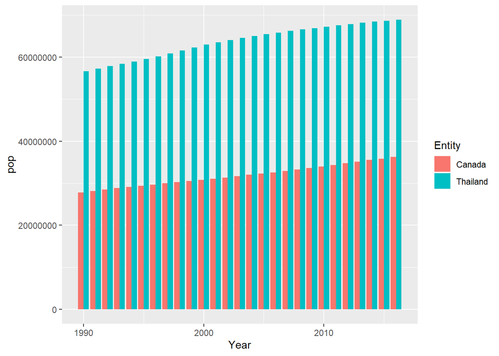

```r
ggplot(WCT_data %>% filter(Entity != "World"))+
  geom_col(aes(Year,pop,fill = Entity),position = "dodge")
```

### Internet Infrastructure

While both Canada and Thailand has similar raw numbers of internet users, Thailand’s larger populace means that less of Thailand has access to reliable wired networks. However, much like Myanmar, there is a large spike in mobile access, far surpassing Canada and the global average. This seems to indicate that mobile subscription is often a substitute in places with poorer internet access.

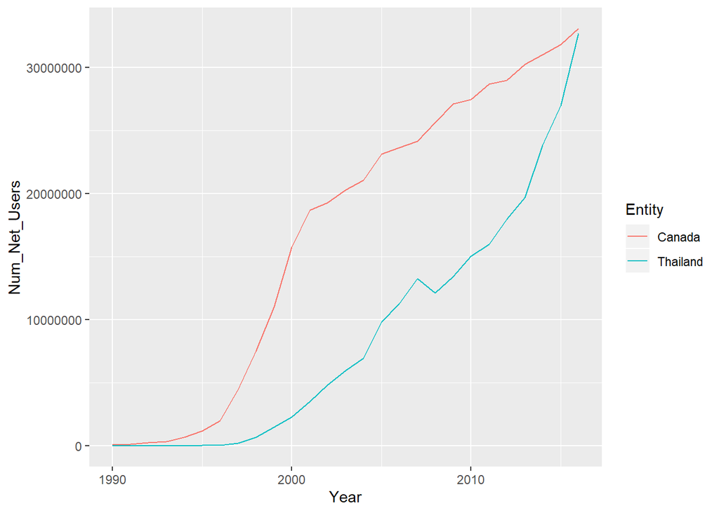

```r
ggplot(WCT_data %>% filter(Entity != "World"))+
  geom_line(aes(Year,Num_Net_Users, color = Entity))
```

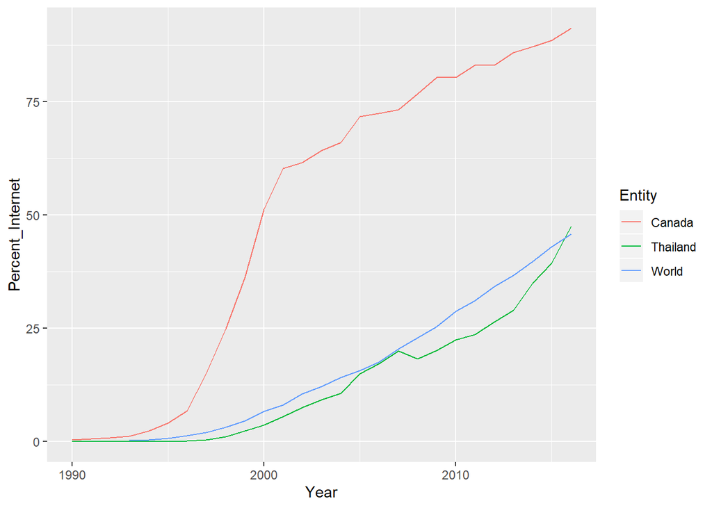

```r
ggplot(WCT_data)+
  geom_line(aes(Year,Percent_Internet, color = Entity))
```

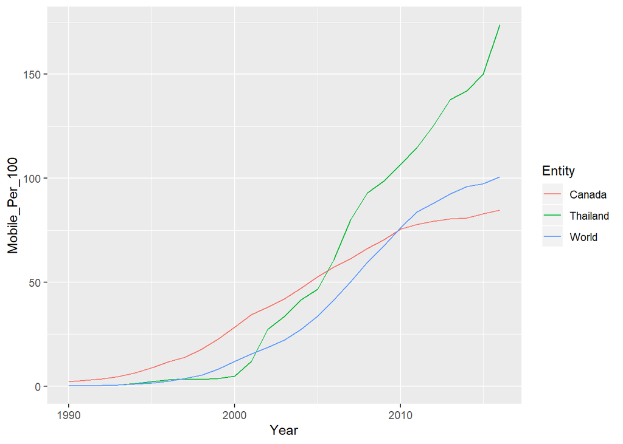

```r
ggplot(WCT_data)+
  geom_line(aes(Year,Mobile_Per_100, color = Entity))
```

### GDP per Capita

This GDP per Capita graph quite clearly illustrates the magnitude of separation between these countries, economically speaking. Canada is a global power, with the adequate funding and infrastructure to adopt internet early on, from the mid 90’s. This may help explain why Thailand has a much higher mobile user rate, again much like Myanmar.

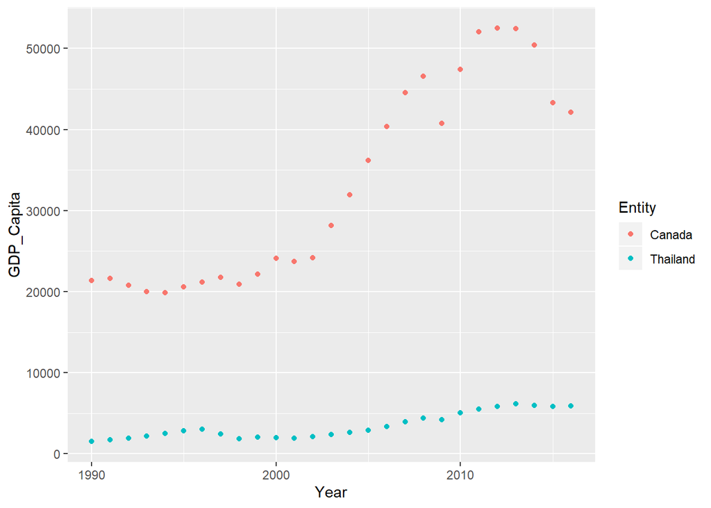

```r
ggplot(WCT_data %>% filter(Entity !="World"))+
  geom_point(aes(Year,GDP_Capita, color = Entity))
```

### Education

The Thai ALO scores plummet from the year 2000. This may be due to the new distraction of the internet, or maybe there was political or social upheaval. But Canada, as a stable, rich nation, maintains or improves their performance.

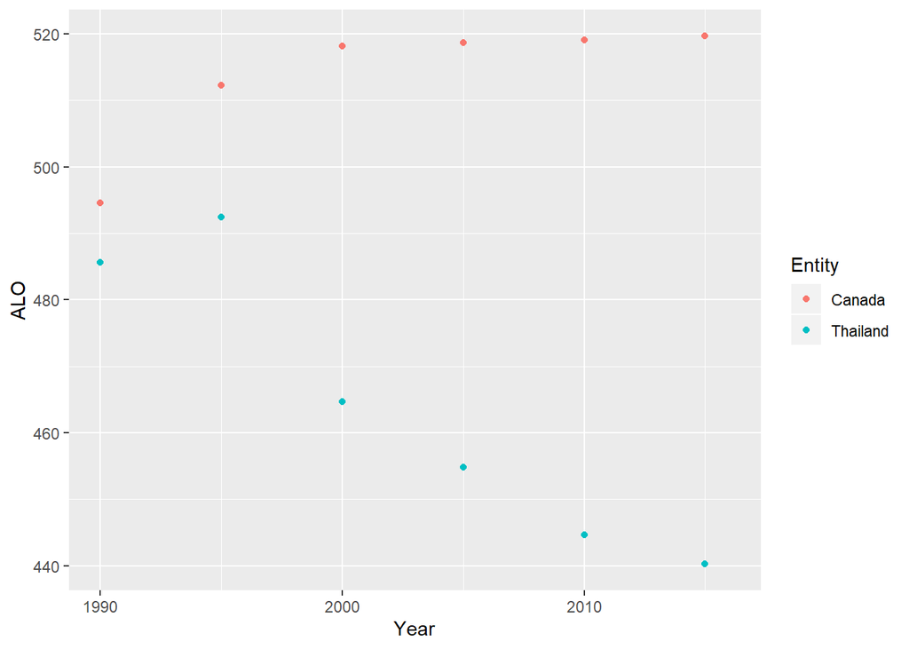

```r
ggplot(WCT_data %>% filter(Entity != "World"))+
  geom_point(aes(Year,ALO, color = Entity))
```

## GDP per capita vs mobile % and internet % Plot in 1995,2005,2015

Finally, to see the impact of mobile and wired internet connection on GDP per Capita over time, we plotted mobile % and internet % by GDP per capita for the years 1995,2005, and 2015.

### Making the Dataframe(s)

```r
a <- GDP %>% slice(1200:6520)  %>% rename(Entity = Country.Name)
b <- pop_raw %>% slice(1216:7058)  %>% rename(Entity = Country.Name)
c <- mobile_use_raw %>% filter(Code != "")
d <- net_per_raw %>% filter(Code != "")

GDP_mob <- inner_join(c,b) %>% inner_join(a) %>% inner_join(d) %>%  mutate(GDP_Capita = GDP/pop) %>% filter(Entity != "World") %>% filter(Year%%5 == 0,Year%%10 != 0)%>% select(Entity, Year,GDP_Capita,Mobile_Per_100,Percent_Internet)

GDP_mob %>% filter(Entity != "Afghanistan") %>% head()
```

```
## # A tibble: 6 x 5
##   Entity   Year GDP_Capita Mobile_Per_100 Percent_Internet
##   <chr>   <int>      <dbl>          <dbl>            <dbl>
## 1 Albania  1995       761.         0               0.0112
## 2 Albania  2005      2709.        49.7             6.04
## 3 Albania  2015      3935.       116.             63.3
## 4 Algeria  1995      1445.         0.0162          0.00177
## 5 Algeria  2005      3100.        41.0             5.84
## 6 Algeria  2015      4160.       108.             38.2
```

### Plotting

As the graphs clearly illustrate, for both mobile and wired internet, The GDP per Capita somewhat correlates with mobile %, but correlates strongly with internet %. This is more evidence that internet access, mobile or otherwise, has at least a small effect on the economic wellbeing of countries.

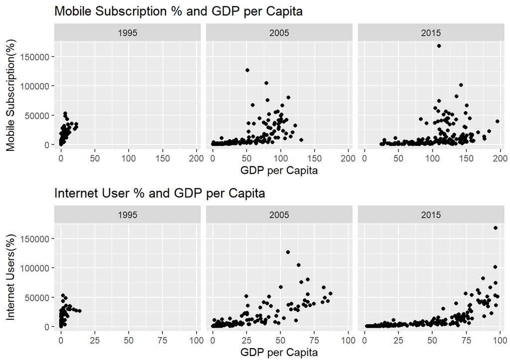

```r
mob <- ggplot(GDP_mob)+
  geom_point(aes(Mobile_Per_100,GDP_Capita))+
  facet_wrap(vars(Year))+
  labs(title = "Mobile Subscription % and GDP per Capita", x = "GDP per Capita", y = "Mobile Subscription(%)")
int <- ggplot(GDP_mob)+
  geom_point(aes(Percent_Internet,GDP_Capita))+
  facet_wrap(vars(Year))+
  labs(title = "Internet User % and GDP per Capita", x = "GDP per Capita", y = "Internet Users(%)")

ggarrange(mob,int, nrow = 2)
```

## Summary/Conclusion

The main idea of this report is to exemplify how internet access affects countries from an economical and educational standpoint. This idea is addressed by examining 6 countries: France, Germany, South Korea, Myanmar, Canada and Thailand, based on their internet availability, GDP and average learning outcome (ALO). In comparing and analyzing these countries it demonstrated that underdeveloped countries preferred mobile usage over broadband, wealthier countries invested into internet access early on, countries with similar economical and educational trends had similar access to the internet. Although it cannot be outright determined if internet access has a positive influence on a country, it can be implied that countries that invested into broadband early have benefited from it from an economical and educational stance. The data selected was limited to many factors that could have helped in exemplifying whether access to the internet affects countries. Regarding economic data consumer price index (CPI), inflation, and unemployment could have given a better understanding of the country’s economic position. Other data like standardized test scores and gradation rates would have helped in contrast education level.